# BIOL 3100 Final Project

# Magmatic Processes in the Alta Stock, Utah: The Impact of Tectonic Dilation on Granite Differentiation

Emmaline Saunders<sup>1</sup>, John M. Bartley<sup>2</sup>, John R. Bowman<sup>2</sup>, Michael Stearns<sup>1</sup>  
*Utah Valley University; 2. University of Utah*

## Introduction & Background

The Alta stock, UT, is part of the Wasatch Intrusive Belt and most well-known for its surrounding metamorphic aureole. Baker (1965) defined two textural units within the Alta stock: an equigranular, more mafic border phase and a porphyritic, more felsic central phase. The contacts between the two phases varies from sharp to gradational. Zircon and titanite U-Pb dates range from ~35–31 Ma and young inward suggesting the margins of the stock were emplaced before the central phase.

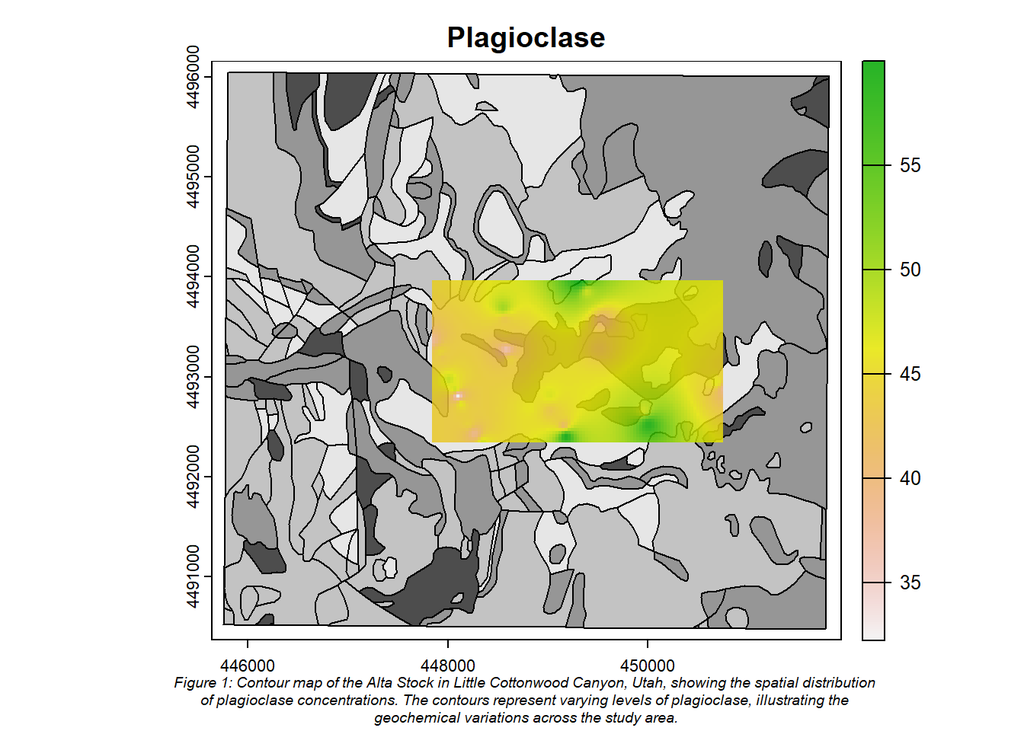

Plagioclase (Plg), quartz and orthoclase (Qtz+Or) mineral modes from 40 Alta stock samples show a negatively sloped linear trend (R2 = 0.86) between equigranular samples with high Plg/low Qtz+Or samples and and an aplitic sample with low Plg/high Qtz+Or.

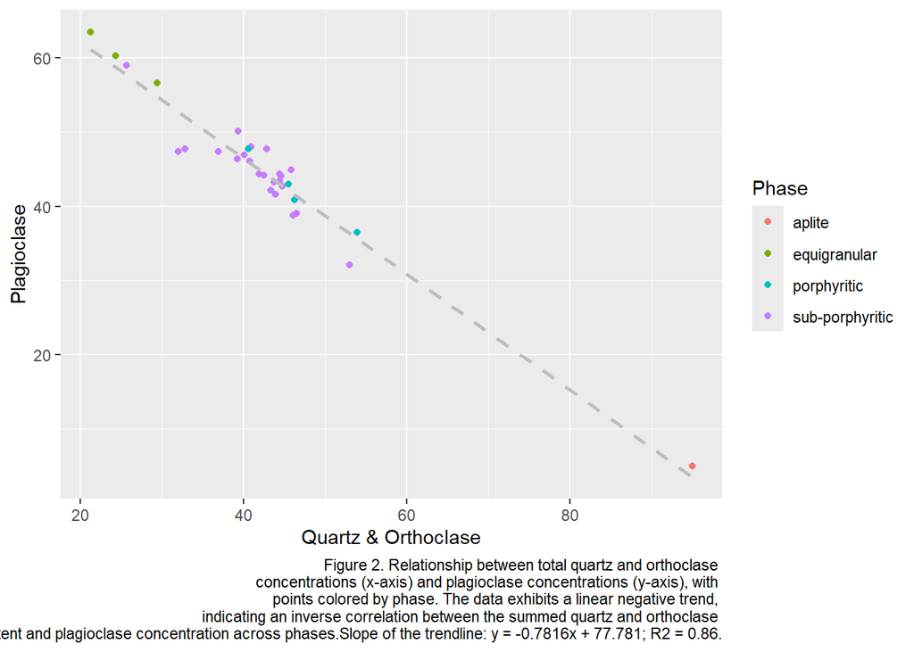

The samples were collected and kept in context. Thin sections were comissioned from the rocks. When one arranges the thin sections based on location, as you go from the center of the intrusion to the outside of it, the phase change is clearly visible. The inner samples are clearly more porphyritic and the outer samples are more equigranular.

## Methods & Results

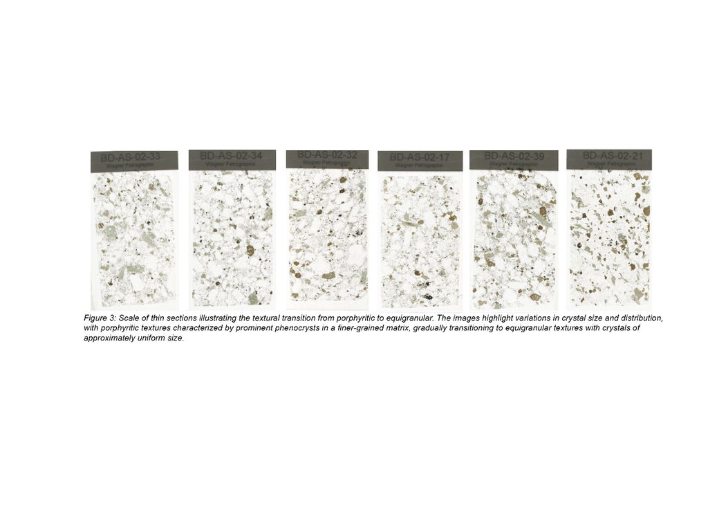

- Porphyritic samples lie between the two end members along the linear trend. Plagioclase within the equigranular samples form an interlocking framework with abundant Plg-to-Plg grain boundaries.
- Crystal plastic deformation (e.g., pressure solution, undulose extinction, mechanical twinning of Plg, and kink bands in biotite) of early-crystallizing phases is more common within the equigranular samples.
- Plg in the porphyritic samples are more often solitary phenocrysts surrounded by a matrix of fine-grained Qtz+Or, and have fewer Plg-to-Plg contacts.

[figure not shown]

[figure not shown]

## Discussion

The steep wall rock contacts, correlated patterns of textural and lithologic variation, and zircon and titanite U-Pb petrochronology are best explained by protracted, tectonic dilation (~0.5 mm a-1) of a dike-like conduit that likely transmittevd magma to the surface and accumulated magmatic rock. The decreasing amount of Plg and of interlocking Plg-Plg grain boundaries toward the center of the stock are interpreted to have resulted from tectonic forces that drove aplitic melt from the partially molten equigranular border phase into the higher melt percent porphyritic central phase rather than a sidewall or gravitational fractionation process.

## Conclusions

The crystal plastic deformation of a plagioclase framework present in the equigranular border phase samples suggests this melt moved after rheological lock up of the magmas. These relationships provides insights into how magmas may differentiate at the emplacement level and highlights the interplay between tectonic forces and petrologic processes within growing intrusive bodies.  
Future research may include:

- Using advanced imaging techniques (e.g., electron backscatter diffraction (EBSD)) to analyze microstructural evidence of melt movement, focusing on textures that document melt migration after rheological lock-up.
- Investigate the cause of the crystal plastic deformation features (e.g., pressure solution, undulose extinction, twinning, kink bands) in the equigranular border phase.
- Quantify the mechanical properties of interlocking plagioclase frameworks in the equigranular phase.